# Statystyka: analiza współzależności cech

TP

1/11/2020

## Analiza współzależności pomiędzy cechami

Problem: czy istnieje związek (zależność) pomiędzy cechami? Dla uproszczenie pomiędzy dwoma cechami, np. czy istneje związek pomiędzy paleniem a chorobą nowotworową, wiekem a prawdopodobieństem zgonu z powodu COVID19 itd

Jaki jest charakter zależności? Jaka jest siła zależności?

## Korelacyjny wykres rozrzutu (korelogram, wykres XY w Excelu, scatter plot)

Obie cechy muszą być mierzalne. W układzie kartezjańskim każdej obserwacji odpowiada kropka o współrzędnych XY.

O występowaniu związku świadczy układanie się kropek według jakiegoś kształtu (krzywej). O braku związku świadczy chmura punktów niepodobna do żadnej krzywej.

Punkty układające się według prostej świadczą o zależności liniowej (wyjątek: linia pozioma lub pionowa) Punkty układające się według krzywej świadczą o zależności nieliniowej.

### Indianie Pima (Arizona/Meksyk)

The Pima Indians of Arizona have the highest reported prevalences of obesity and non-insulin-dependent diabetes mellitus (NIDDM). In parallel with abrupt changes in lifestyle, these prevalences in **Arizona Pimas** have increased to epidemic proportions during the past decades (https://care.diabetesjournals.org/content/17/9/1067)

[figure not shown]

Przykład BMI a poziom glukozy dla Indianek z plemienia Pima (USA/Meksyk)

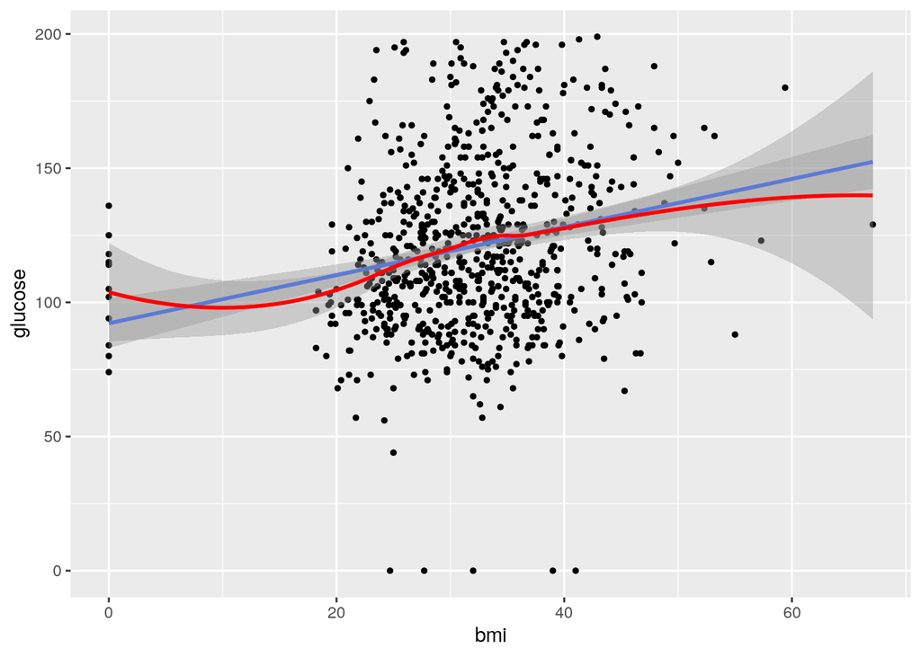

### Testy a zakażeni wg województw w PL

Wg teorii lansowanej przez pewną antyrządową telewizję (wszyscy wiemy o jaką TV chodzi:-)) Liczba zarażonych w PL jest zaniżona bo wykonuje się ciągle zbyt mało testów. Można zweryfikować (w naiwny sposób) to stwierdzenie wykreślając liczę testów oraz liczbę zarażonych i/lub zmarłych wg województw

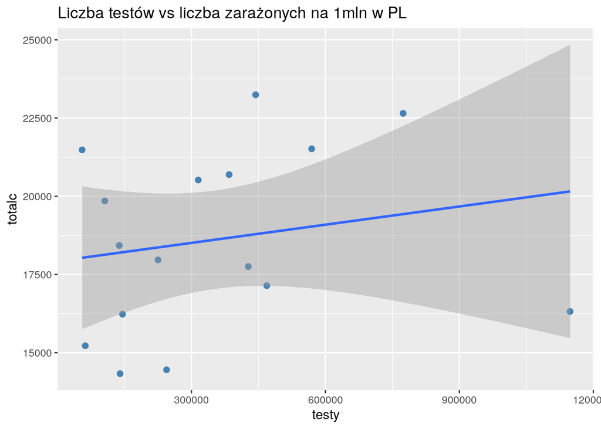

oraz

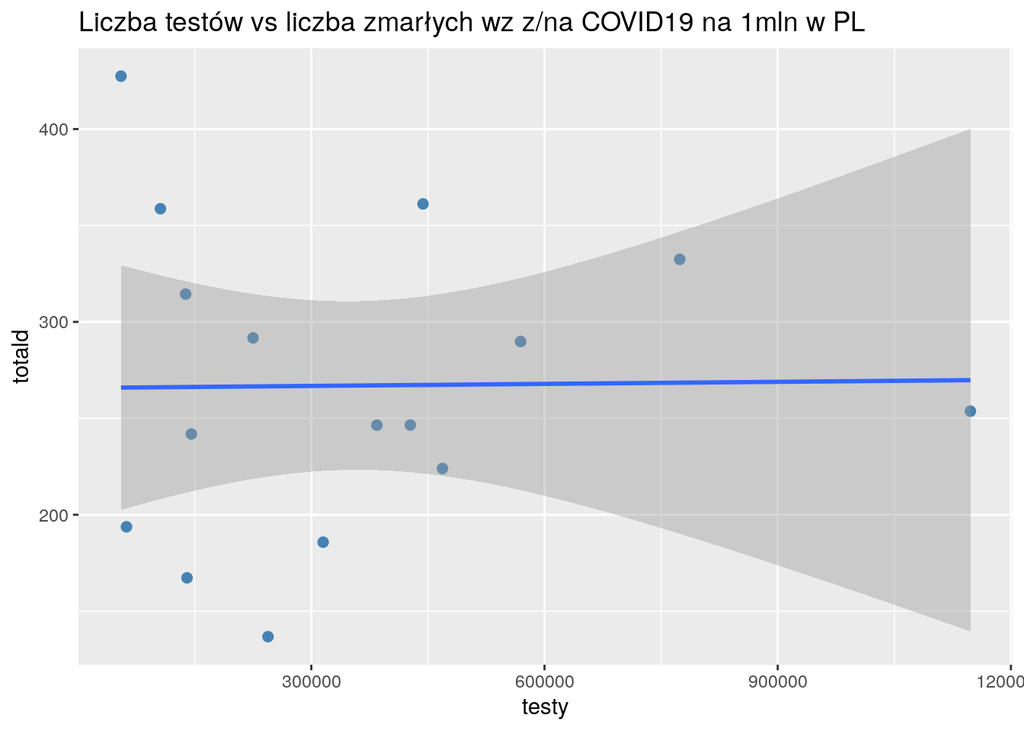

Wniosek: twierdzenie antyrządowej TV wydaje się słabo uzasadnione zwłaszcza w odniesieniu do zależności testy vs zmarli. Dla pewności to sama zależność dla danych z wybranych krajów świata (dane pobrane ze strony ECDC)

[figure not shown]

Hmm…

Rodzaje zależności (brak, liniowa, nieliniowa)

### Spożycie mięsa a GDP (Świat 2013 rok)

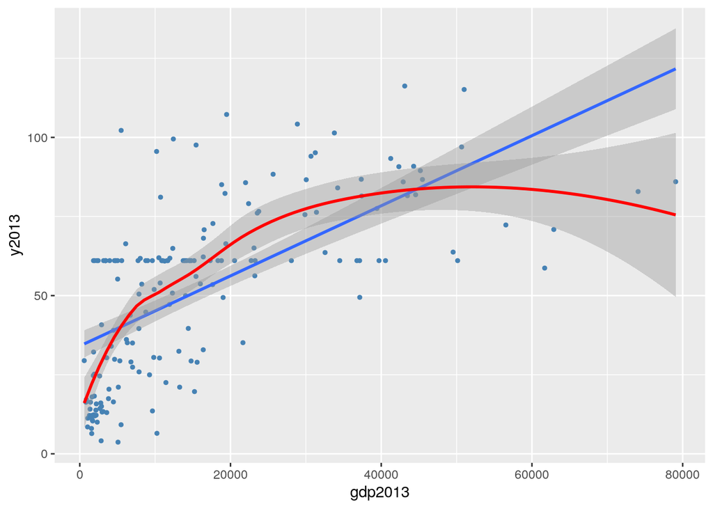

Obserwacje nietypowe (odstające)

## Wykres mozaikowy (mosaic plot)

W przypadku danych niemierzalnych do wizualizacji stosuje się **wykres mozaikowy**. Przykładowo plik smoker.csv zawiera dane dotyczące palenia (pali, palił-nie-pali, nigdy-nie-palił) oraz statusu społeczno-ekonomicznego (wysoki, średni, niski). Liczebności poszczególnych kategorii są następujące:

```
##      Smoke         SES
##  current:116   High  :211
##  former :141   Low   : 93
##  never  : 99   Middle: 52
```

Wykres mozaikowy wygląda zaś następująco (kolorem wyróżniono SES):

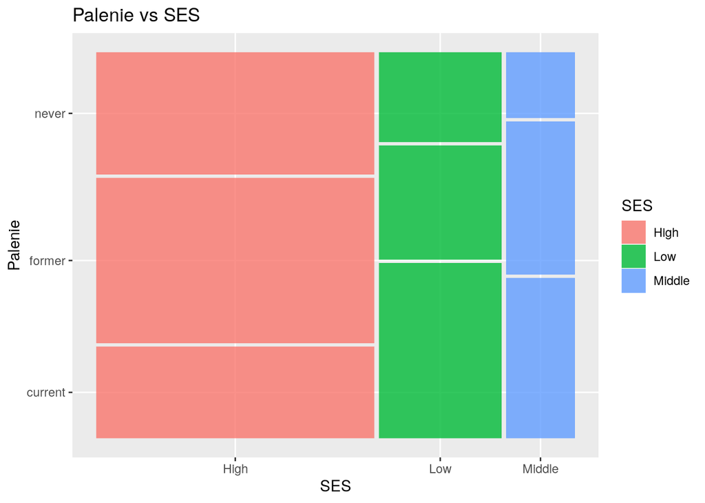

## Tablice korelacyjne (dwudzielne, two-way tables)

Pozwalają ustalić zależność pomiędzy zmiennymi niekoniecznie mierzalnymi (palenie a nowotwór)

Rodzaje zależności: jest/nie ma

```
##
##           High Low Middle
##   current   51  43     22
##   former    92  28     21
##   never     68  22      9
```

### Rozkłady warunkowe i brzegowe

```
## [1] 356
```

```
##
## current  former   never
##     116     141      99
```

```
##
##   High    Low Middle
##    211     93     52
```

```
##
##                 High        Low     Middle
##   current 0.14325843 0.12078652 0.06179775
##   former  0.25842697 0.07865169 0.05898876
##   never   0.19101124 0.06179775 0.02528090
```

```
##
##                 High        Low     Middle
##   current 0.43965517 0.37068966 0.18965517
##   former  0.65248227 0.19858156 0.14893617
##   never   0.68686869 0.22222222 0.09090909
```

```
##
##                High       Low    Middle
##   current 0.2417062 0.4623656 0.4230769
##   former  0.4360190 0.3010753 0.4038462
##   never   0.3222749 0.2365591 0.1730769
```

### Tablice wielodzielne dla danych ilościowych

```
## Weight
##  (70,80]  (80,90] (90,100]
##     2830     1360     2935
```

## Iloraz szans (odds ratio)

Linus Pauling (laureat nagrody Nobla/witamina C). Podawanie witaminy C a przeziębienie/brak przeziębienia.

[figure not shown]

```
                | Cold  No Cold | Totals
--------------+-----------------+-------
Placebo       |   31    109 | 140
Ascorbic Acid |   17    122 | 139
--------------+-----------------+-------
Totals        |   48    231 | 279
```

Dla przypomnienia (wykres mozaikowy):

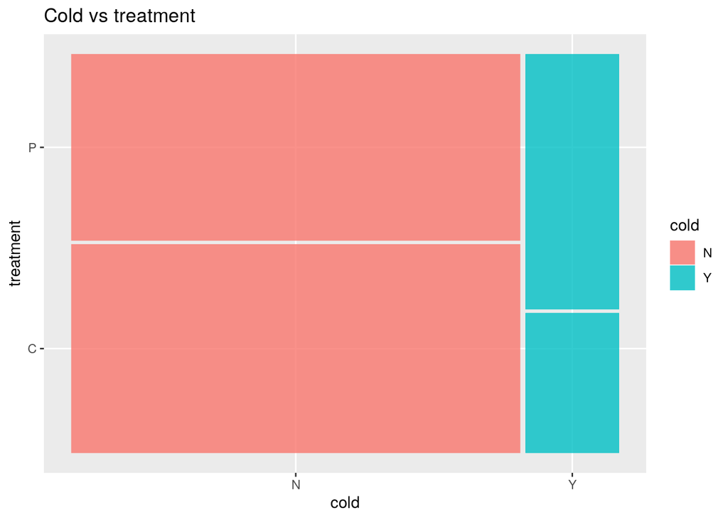

Dwa **rozkłady brzegowe**: Brał placebo/Brał witaminę C (140 vs 139) Zachorował/nie zachorował (48/231)

Cztery **rozkłady warunkowe**: Brał placebo oraz zachorował/nie zachorował 31 vs 109 lub $31/(31+109)=0,2214$ oraz $109/(109+31.0) = 0.7785$. Interpretacja: 22,14% tych którzy brali placebo zachorowało, a 77,85% nie zachorowało.

Brał witaminę C oraz zachorował/nie zachorował 17 vs 122 lub $17/(17+122.0) = 0.1223$ oraz $122/(17+122.0) = 0.8776$ Interpretacja: 12,23% tych którzy brali witaminę C zachorowało, a 87,76% nie zachorowało.

Zachorował oraz brał placebo/witaminę C 31 vs 17 Nie zachorował oraz brał placebo/witaminę C 109 vs 122

Iloraz szans to iloraz częstotliwości warunkowych. Odds of getting a cold versus not getting a cold given that a person took a placeboL: 31/109 albo 22,14/77,85 = 0,28 Szansa że ktoś zachoruje a brał placbo wynosi 0,28%. Szansa, że ktoś zachoruje a brał witaminę C wynosi 17/122=0,13

Właściwości OR: jeżeli równe 1 to sukces/porażka równie prawdopodobne; jeżeli większe od 1 to sukces bardziej prawdopodobny; jeżeli mniejsz od 1 to porażka jest bardziej prawdopodobna.

## Test chi-kwadrat (Pearsona)

Rodzaje zależności: jest/nie ma

Idea jest prosta: porównujemy liczebności tablicy korelacyjnej z **liczebnościami teoretycznymi** to znaczy takimi które wynikają z przyjęcia założenia że cechy XY są niezależne. Innymi słowy oceną wielkości związku jest różnica pomiędzy **liczebnościami teoretycznymi** a **liczebnościami empirycznym**.

### Narciarze leczeni witaminą C

```
                | Cold  No Cold | Totals
--------------+-----------------+-------
Placebo       |   31    109 | 140
Ascorbic Acid |   17    122 | 139
--------------+-----------------+-------
Totals        |   48    231 | 279
```

Gdyby XY były niezależne to

```
              | Cold    No Cold | Totals
--------------+-----------------+-------
Placebo       | 24,1    115,9   | 140
Ascorbic Acid | 23,9    115,1   | 139
--------------+-----------------+-------
Totals        |   48    231 | 279
```

Policzmy różnice $(31 - 24,1) + (17 - 23,9) = 0$. Dla drugiej kolumny oczywiście też jest zero. Ale różnice podniesione do kwadratu już nie będą się zerowały: $(31 - 24,1)^2 + (17 - 23,9) + (109 - 115,9) + (122 - 115,1) = 47,6 + 47,6 + 47,6 + 47,6 = 190,44$

Im większa różnica tym nasze przekonanie że istnieje związek pomiędzy cechami jest większe (co oczywiste). Pytanie kiedy jest **dużo**.

[output not shown]

## Pomiar siły zależności: współczynnik korelacji liniowej Pearsona

Kowariancja/współczynnik korelacji liniowej Pearsona

$$cov (x, y) = 1/n \sum_{i=1}^N (x - \bar x) (y - \bar y)$$

Przykład graficzny: kowariacja zależy od rozproszenia (im większe tym większa), ma dziwną jednostkę oraz zależy od wybranych skal (tony vs gramy)

https://tinystats.github.io/teacups-giraffes-and-statistics/05_correlation.html

Dlatego do pomiaru związku pomiędzy cechami nie używa się kowariancji ale współczynnika korelacji (liniowej, *Pearson linear correlation coefficient*):

$$r_xy = cov(xy) / (S_x \cdot S_y)$$

Miara niemianowana, o wartościach ze zbioru $[-1;1]$; Skrajne wartości $\pm 1$ świadczą o związku funkcyjnym (wszystkie punkty układają się na linii prostej); wartość zero świadczy o braku związku (linia pozioma/pionowa)

Interpretacja opisowa: wartości powyżej 0,9 świadczą o silnej zależności

## Pomiar siły zależności: współczynnik korelacji rang

Współczynnik korelacji rang (Spearmana vel *Spearman’s Rank-Order Correlation*) może być stosowany w przypadku gdy cechy są mierzone w skali porządkowej (lub lepszej)

Obliczenie współczynnika Spearmana dla $N$ obserwacji na zmiennych XY polega na zamianie wartości XY na **rangi** (numery porządkowe od $1...N$). Następnie stosowana jest formuła Pearsona, tj. ($\tau_x$ oraz $\tau_y$ oznaczają **rangi**):

$$\rho_xy = cov(\tau_x, \tau_y) / ( S_{\tau_x} \cdot S_{\tau_y} )$$

Współczynnik $\rho_xy$ to także miara niemianowana, o wartościach ze zbioru [-1;1];

W podręcznikach można też spotkać formułę alternatywną:

$$r_s = 1 - \frac{6 x \sum_{i=1}^N d_i^2}{ N(N^2 -1)}$$

gdzie $d_i$ oznacza różnicę między rangami dla cechy X oraz $Y$, tj. $d_i = \tau_{x_i} - \tau_{y_i}$. Wymagany jest aby $d_i$ były różne od siebie. Można też spotkać (w podręcznikach) przykłady użycia formuły alternatywnej dla rang identycznych, wówczas (dla $k$ identycznych rang, zamienia się je na wartości średnie) $d_i = \frac{1}{k}\sum_i=1^k d_i^k$. Raczej nie zalecane…

### Przykład: testy z zakażeni wg województw w PL

Współczynnik Pearsona i Spearmana dla zależności między liczbą testów a liczbą zarażonych wirusem COVID19 (PL/województwa):

```
## [1] 0.1962708
```

```
## [1] 0.2852941
```

Współczynnik Pearsona i Spearmana dla zależności między liczbą testów a liczbą zmarłych z powodu COVID19:

```
## [1] 0.01310447
```

```
## [1] -0.005882353
```

### Przykład: spożycie mięsa

Współczynnik Pearsona i Spearmana dla zależności między spożyciem mięsa w 1980 a spożyciem mięsa w 2013 roku (zmienna objaśniana):

```
## [1] 0.6823158
```

```
## [1] 0.6845429
```

## Regresja liniowa

Obie cechy muszą być mierzone za pomocą skali co najmniej interwałowej.

W przypadku gdy zależność dotyczy dwóch cech mówi się o **regresji prostej**. Regresja wieloraka to zależność pomiędzy jedną zmienną objaśnianą (Y) a wieloma zmiennymi objaśniającymi ($X_1, ... X_k$)

Liniowa funkcja regresji ma postać:

$$Y = a \cdot X + b$$

Współczynnik $a$ ma jasną interpretację: jeżeli wartość zmiennej $X$ rośnie o jednostkę to wartość zmiennej Y zmienia się przeciętnie o $a$. Wyraz wolny zwykle nie ma sensu (formalnie jest to wartość zmiennej $Y$ dla $X=0$)

Oznaczmy przez $y_i$ wartości obserwowane (empiryczne) a przez $\hat y_i$ $wartości teoretyczne$ (leżące na prostej linii regresji). Wartości $a$ oraz $b$ wyznacza się minimalizując: $_{i=1}^Ny_i - y_i $ (suma kwadratów odchyleń wartości empirycznych od wartości teoretycznych ma być minimalna)

### Ocena dopasowania

Średni błąd szacunku (MSE mean squared error). Oznaczając *resztę* jako: $e_i = y_i - \hat y_i$, definiujemy **średni błąd szacunku** jako: $S_e = (e_i^2 / n -k). (Przy okazji $S_e^2$ nazywamy **wariancją resztową**)

### Współczynnik zbieżności i determinacji

Suma kwadratów reszt (albo odchyleń wartości teoretycznych od wartości empirycznych, albo suma kwadratów błędów vel **resztowa suma kwadratów**): $RSK = \sum (y_i - \hat y_i)^2$. Suma kwadratów odchyleń **wartości empirycznych** od średniej (**ogólna suma kwadratów**): $OSK = \sum (y_i - \bar y)^2$ Suma kwadratów odchyleń **wartości teoretycznych** od średniej (**wyjaśniona suma kwadratów**): $WSK = \sum (\hat y_i - \bar y)^2$

Można wykazać, że $OSK = WSK + RSK$. Współczynnik zbieżności to $R^2 = WSK/OSK$. Współczynnik determinacji to $\Phi^2 = RSK/OSK$.

Współczynniki przyjmują wartość z przedziału $[0,1]$ lub $[0, 100]$% Interpretacja współczynników: procent zmienność wyjaśniane/nie wyjaśniane przez linię regresji.

Zerowa wartość parametru $a$

Jeżeli: $Y= 0 \cdot X + b$, to $Y = b$ czyli nie ma zależności pomiędzy $XY$. Wartości $a$ bliskie zero wskazują na słabą zależność pomiędzy cechami. Przyjmijmy

$$\hat Y = a \cdot \hat X + b + e$$

w tym zapisie **obserwowana linia regresji** jest równa linii teoretycznej $Y = a \cdot X + b$ plus błąd losowy. (przy czym losowość błędu przejawia się m.in w tym, że nie ma on charakteru systematycznego, tj. jest określona jako zero plus/minus cośtam)

Można teraz zadać pytanie jeżeli $a=0$ to jakie jest prawdopodobieństwo że współczynnik $\hat a$ oszacowany na podstawie $n$ obserwacji mierzonych z błędem $e$ będzie (co do wartości bezwzględnej) większy niż $a_e$. Albo inaczej: otrzymaliśmy $a_e$, jakie jest prawdopodobieństwo otrzymania takiej wartości (lub mniejszej co do wartości bezwzględnej) przy założeniu że istotnie $a=0$.

Jeżeli takie prawdopodobieństwo jest duże to zakładamy że być może $a=0$ a jeżeli małe to że $a \not0$. Duże/małe przyjmujemy arbitralnie, zwykle jest to $0,1$, $0,05$ lub $0,01$.

Pakiety statystyczne szacują ww. prawdopodobieństwo, zwykle oznaczając je *prob*. Reasumując jeżeli przyjeliśmy $0,05$ jako wartość na tyle małą że niemożliwą w realizacji oraz otrzymaliśmy $prob=0,006$ to mówimy że współczynnik $a$ jest **istotnie różny od zera**.

Testowanie istotności współczynnika regresji jest ważnym kryterium oceny jakości dopasowania. Regresja z **nieistotnym** współczynnikiem nie może być podstawą do interpretowania zależności pomiędzy XY.

### BMI a glukoza dla Indian Pima

Szacujemy liniową funkcję regresji dla zmiennych glucose (objaśniana) oraz bmi (objaśniająca):

```
## (Intercept)         bmi
##   92.212896    0.896509
```

```
## [1] 0.04887242
```

```
##              Estimate Std. Error   t value
## (Intercept) 92.212896  4.7082932 19.585207
## bmi          0.896509  0.1428985  6.273746
##                                                                                  Pr(>|t|)
## (Intercept) 0.000000000000000000000000000000000000000000000000000000000000000000001478974
## bmi         0.000000000589141252708448832510577241613298690725564199510699836537241935730
```

### Testy a zmarli wg województw (PL)

```
##      (Intercept)            testy
## 265.747361489396   0.000003530217
```

```
## [1] 0.0001717273
```

```
##                     Estimate     Std. Error    t value       Pr(>|t|)
## (Intercept) 265.747361489396 32.57264599659 8.15860528 0.000001088874
## testy         0.000003530217  0.00007199137 0.04903666 0.961582788709
```

```
##   (Intercept)    tests_done
## 311.421050064   0.003171251
```

```
## [1] 0.02352672
```

```
##                  Estimate   Std. Error   t value    Pr(>|t|)
## (Intercept) 311.421050064 96.543664682 3.2257016 0.003281042
## tests_done    0.003171251  0.003931861 0.8065521 0.426972229
```

### GDP a spożycie mięsa

Im większe GDP tym więcej ludzie jedzą mięsa:

```
##  (Intercept)      gdp2013
## 34.084768118  0.001107544
```

```
## [1] 0.4087518
```

```
##                 Estimate    Std. Error  t value
## (Intercept) 34.084768118 2.23247986990 15.26767
## gdp2013      0.001107544 0.00009956108 11.12427
##                                               Pr(>|t|)
## (Intercept) 0.0000000000000000000000000000000003049703
## gdp2013     0.0000000000000000000003460772431846800413
```

Prognozowanie: ile wyniesie liczba zmarłych gdyby wykonywani p testów. Ile wyniesie poziom glukozy

## Regresja logistyczna

Iloraz szans (*odds ratio*), to stosunek sukcesów do porażek (zdrowi/chorzy):

$$O_R = \frac{p_1}{p_0}$$

(W ogólności $log(odds) = a_0 + a_1 \cdot x_1 + \ldots + a_k \cdot x_k$)

Regresja logistyczna w najprostrzej postacji ma postaci:

$$log(O_R) = a \cdot x + b$$

Interpretacja: jeżeli X wzrośnie o jednostkę to logarytm ilorazu szans wzrośnie o $log(O_R)$ lub iloraz szans wzrośnie i $exp^{log(O_R)} \cdot 100 - 100$ procent.

## Przykład

Załóżmy że chcemy zbadać zależność pomiędzy liczbą wypalonych papierosów a zachorowalnością na nowotwór płuc, tj.:
$$log(O_R) = a \cdot P + b$$
, gdzie zmierzyliśmy prosząc palącego o podanie przez ile lat wypalał minimum x papierosów dziennie. Załóżmy dalej że P wyraziliśmy w 10000 papierosów (około 2lata palenia po 15 papierosów/dzień) i otrzymaliśmy $log(O_R) = 0,1$. Wówczas $O_R = 1.1 \cdot 100 - 100 = 10$ procent. Każde kolejne 10 tys papierosów zwiększa $O_R$ o 10%.

https://stats.idre.ucla.edu/other/mult-pkg/faq/general/faq-how-do-i-interpret-odds-ratios-in-logistic-regression/

## Regresja kwantylowa

Innym razem

## Materiały dodatkowe

https://bookdown.org/mpfoley1973/data-sci/two-way-tables.html

https://online.stat.psu.edu/stat504/node/69/

https://rstudio-pubs-static.s3.amazonaws.com/344010_1f4d6691092d4544bfbddb092e7223d2.html